# zg21696_EMATM0061_C_Report

## 3.6 The introduction of kd tree and the efficiency and performance comparision

KNN is the representative for “Lazy Learning”. It means that some algorithms do not need computing model parameters in data training. However, to some degree, these algorithms just delay the time on data training to the data test (Wikipedia, 2021). KNN needs to utilize all training data in the test stage for predict results. Based on the time complexity in the test stage, O(N*D), where N is the number of a sample set, and D is the number of dimensions, a conclusion can be made that if N or D becomes enormous, the time complexity and computational volume becomes large. It also means KNN are not good at to deal with a very high dimensions dataset (Tjoa, 2013).

KD tree is a kind of tree data structure that stores instance points in multidimensional space for rapid retrieval. If the dataset for training is stored in the KD tree in advance, part of the time complexity of KNN can be transferred to the space complexity, and the efficiency can be improved in the data test stage (Schmatz, 2019).

The following will apply for “RANN” package written by Jefferis, a wrapper for Approximate Nearest Neighbours (ANN) C++ library, where nn2 function uses the KD tree to store training datasets to search the k number of near neighbours for each point in a test dataset (Jefferis, 2019).

Because the amount of breast cancer data is too small, in order to view more clearly the time consumption comparison between KNN search with KD tree and traditional KNN search, these two methods are repeated to execute a 1000 times.

```r
library(RANN)
knn_on_kdtree = system.time(lapply(1:1000,function(x) test1 <- nn2(train_validation_data[-1], k=11, query = test_data[-1])))[3]
normal_knn = system.time(lapply(1:1000,function(x) test2 <-  kknn(diagnosis~., train_validation_data, test_data, k = 11)))[3]
```

From the figures, it can be seen that the time elapsed on KNN search on a KD tree is less than traditional KNN search

```r
time_table = data.frame(Type = c("KNN search on a KD Tree","Traditional KNN"), Time = c(as.numeric(knn_on_kdtree),as.numeric(normal_knn)))
time_table
```

```
##                      Type Time
## 1 KNN search on a KD Tree 2.77
## 2         Traditional KNN 9.69
```

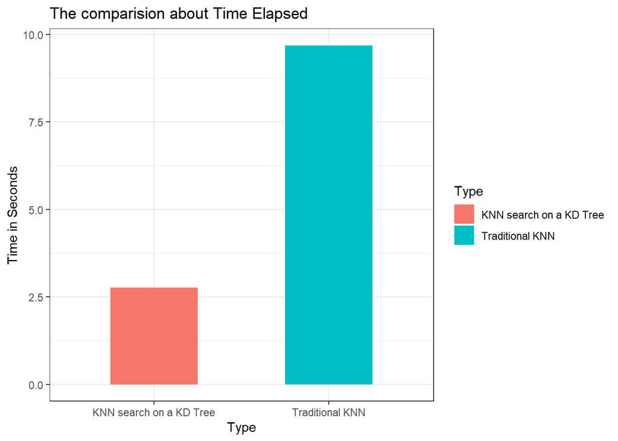

```r
ggplot(data = time_table, aes(x=Type,y=Time,fill=Type))+
  geom_bar(stat="identity",width=0.5)+
  labs(title = "The comparision about Time Elapsed", y="Time in Seconds") +
  theme(plot.title = element_text(hjust = 0.5))+ theme_bw()
```

```r
compute_mode =  function(vec){
  temp = table(vec)
  nums_of_mode <- max(temp)
  mode = as.numeric(names(temp))[temp == nums_of_mode]
  return(mode)
}

kdtree_knn = function(train,test){
  neighbours_list =nn2(train[-1], k=11, query = test[-1])[["nn.idx"]]
  row_num = neighbours_list%>%nrow()
  preds = c()
  for(x in 1:row_num){
    index = neighbours_list[x,]
    neighbours = train%>%filter(row_number()%in%index)%>%select(diagnosis)
    preds = c(preds,compute_mode(neighbours))
  }
  return(preds)
}

traditional_knn = function(train,test){
  check_knn = kknn(diagnosis~., train, test, k = 11)
  pred_vector = fitted(check_knn)
  return(pred_vector)
}
```

In terms of performance comparison, the gap between these methods is not very obvious.

```r
preds_kdtree = kdtree_knn(train_validation_data,test_data)
preds_tradition = traditional_knn(train_validation_data,test_data)
truth = test_data$diagnosis
kd_preds_table = table(truth,preds_kdtree)
confusionMatrix(kd_preds_table)
```

```
## Confusion Matrix and Statistics
##
##      preds_kdtree
## truth  0  1
##     0 47 10
##     1  1 85
##
##                Accuracy : 0.9231
##                  95% CI : (0.8665, 0.961)
##     No Information Rate : 0.6643
##     P-Value [Acc > NIR] : 2.251e-13
##
##                   Kappa : 0.8352
##
##  Mcnemar's Test P-Value : 0.01586
##
##             Sensitivity : 0.9792
##             Specificity : 0.8947
##          Pos Pred Value : 0.8246
##          Neg Pred Value : 0.9884
##              Prevalence : 0.3357
##          Detection Rate : 0.3287
##    Detection Prevalence : 0.3986
##       Balanced Accuracy : 0.9370
##
##        'Positive' Class : 0
##
```

```r
trad_preds_table = table(truth,preds_tradition)
confusionMatrix(trad_preds_table)
```

```
## Confusion Matrix and Statistics
##
##      preds_tradition
## truth  0  1
##     0 49  8
##     1  2 84
##
##                Accuracy : 0.9301
##                  95% CI : (0.8752, 0.966)
##     No Information Rate : 0.6434
##     P-Value [Acc > NIR] : 9.161e-16
##
##                   Kappa : 0.8515
##
##  Mcnemar's Test P-Value : 0.1138
##
##             Sensitivity : 0.9608
##             Specificity : 0.9130
##          Pos Pred Value : 0.8596
##          Neg Pred Value : 0.9767
##              Prevalence : 0.3566
##          Detection Rate : 0.3427
##    Detection Prevalence : 0.3986
##       Balanced Accuracy : 0.9369
##
##        'Positive' Class : 0
##
```

## 3.7 Further Consideration

When preparing this assignment, I viewed documentation of many different R packages about KNN algorithm. I found they are all not perfect. Some lack feature-scaling methods as the parameter, some lack the distance measures as the parameter and some lack the method about weighting. But they all contain K. I think the biggest reason is that k as the hyperparameter in KNN is much more important than other hyperparameters. But in other algorithms, it is not easy to compare the importance of all different hyperparameters intuitively. Then, I searched Google Scholar and found that most of the papers about hyperparameters are on tuning parameters for different algorithms, but the amount of studies on evaluating and comparing the importance of the hyperparameters of a specific algorithm is still small. Therefore, I think how to evaluate and quantify hyperparameters importance from a mathematical and theoretical perspective may be a direction that deserves to study.

## 3.8 References

[1] Onel Harrison (2018).Machine Learning Basics with the K-Nearest Neighbors Algorithm [online]. Accessed: 18 December 2021. Available: https://towardsdatascience.com/machine-learning-basics-with-the-k-nearest-neighbors-algorithm-6a6e71d01761

[2] Harsh H (2016). Why does knn get effected by the class imbalance? [online]. Accesssed: 18 December 2021. Available: https://www.quora.com/Why-does-knn-get-effected-by-the-class-imbalance

[3] W.H.Wolberg, W.N.Street,O.L.Mangasarian (1995). Breast Cancer Wisconsin (Diagnostic) Data Set [online]. Acessed: 18 December 2021. Available: https://archive.ics.uci.edu/ml/datasets/Breast+Cancer+Wisconsin+%28Diagnostic%29

[4] S.A.Gokte (2020). Most Popular Distance Metrics Used in KNN and When to Use Them [online]. Accessed: 21 December 2021. Available: https://www.kdnuggets.com/2020/11/most-popular-distance-metrics-knn.html

[5] H.Dubey, V.Pudi (2013). Class Based Weighted K-Nearest Neighbor over Imbalance Dataset [online]. Accessed: 21 December 2021. Available: https://www.semanticscholar.org/paper/Class-Based-Weighted-K-Nearest-Neighbor-over-Dubey-Pudi/3b64eb13f3f18f8356d8efdb81eccbb27722cbeb

[6] Jason Brownlee (2020). Hyperparameter Optimization With Random Search and Grid Search [online]. Accessed: 22 December 2021. Available: https://machinelearningmastery.com/hyperparameter-optimization-with-random-search-and-grid-search/

[7] Mouselimis Lampros (2016).Random search and resampling techniques in R [online]. Acessed: 19 December 2021. Available: http://mlampros.github.io/2016/03/14/random_search_R/  
[8] Wikipedia (2021). Lazy learning [online]. Accessed: 22 December 2021. Available: https://en.wikipedia.org/wiki/Lazy_learning

[9] Steve Tjoa (2013). StackOverflow. Nearest neighbors in high-dimensional data? [online]. Accessed: 19 December 2021. Available: https://stackoverflow.com/questions/5751114/nearest-neighbors-in-high-dimensional-data

[10] Steven Schmatz (2019). Quora. How does a k-d tree find the K nearest neighbours? [online]. Accessed: 20 December 2021. Available: https://www.quora.com/How-does-a-k-d-tree-find-the-K-nearest-neighbors

[11] Gregory Jefferis (2019). RAAN [online]. Acessed: 20 December 2021. Available: https://www.rdocumentation.org/packages/RANN/versions/2.6.1